# Homework 1 - Time Series Analysis and Dimensionality Reduction using PCA

Author: Joshua Zhong

Assignment completed as part of NYU's FRE 7773 Machine Learning in Financial Engineering Course taught by Professor Amine Aboussalah

1. Time Series Analysis: U.S. Quarterly GDP data (1947-2023) - Available from the Federal Reserve Economic Data (FRED) repository (Gross Domestic Product (GDP) | FRED | St. Louis Fed)
2. Principal Component Analysis: UCI Machine Learning Repository - Wine Quality Dataset with 12 attributes (Wine Quality - UCI Machine Learning Repository)

#### Dependencies

```python
# Imports needed to ensure proper reading of CSV file
import pandas as pd
from pathlib import Path

# Imports needed for graphing and data frame manipulation
import numpy as np
import matplotlib.pyplot as plt

# Imports needed for decomposition
from statsmodels.tsa.holtwinters import ExponentialSmoothing

# Imports needed for ADF test
from statsmodels.tsa.stattools import adfuller

# Imports needed for ACF/PACF Plots
import statsmodels.tsa.api as ts
from statsmodels.graphics.tsaplots import plot_acf
from statsmodels.graphics.tsaplots import plot_pacf


# Imports needed to for Evaluation Metrics
from sklearn.metrics import mean_squared_error, mean_absolute_error

# Imports to fit SARIMA model
from statsmodels.tsa.statespace.sarimax import SARIMAX

# Imports needed for auto_arima for our second candidate model

# ==== Note ====
# Because pmdarima likely hasn't been updated, it originally generated the following error:
# ValueError: numpy.dtype size changed, may indicate binary incompatibility
# In order to utilize pmdarima, you needed to use an older version of the Numpy library
# !pip uninstall numpy
# !pip install numpy==1.26.4
# ==============

import pmdarima as pm
```

## Task 1: Time Series Analysis with Linear Models

### Objective

Using the U.S. Federal Reserve's Quarterly GDP data from 1947 to 2023, we will analyze the time series data to identify patterns, determine appropriate linear model parameters, and compare model performance

### Data Exploration and Preprocessing

First we load in the data, and do some preliminary exploratory data analysis

```python
gdp_data = pd.read_csv("GDP.csv")

print(gdp_data.head())
print(gdp_data.info())
```

```
  observation_date      GDP
0       1947-01-01  243.164
1       1947-04-01  245.968
2       1947-07-01  249.585
3       1947-10-01  259.745
4       1948-01-01  265.742
<class 'pandas.core.frame.DataFrame'>
RangeIndex: 308 entries, 0 to 307
Data columns (total 2 columns):
 #   Column            Non-Null Count  Dtype
---  ------            --------------  -----
 0   observation_date  308 non-null    object
 1   GDP               308 non-null    float64
dtypes: float64(1), object(1)
memory usage: 4.9+ KB
None
```

Since observation date is of type 'Object', we change it to ensure that it's of type datetime

```python
gdp_data['observation_date'] = pd.to_datetime(gdp_data['observation_date'])
print(gdp_data.info())
```

```
<class 'pandas.core.frame.DataFrame'>
RangeIndex: 308 entries, 0 to 307
Data columns (total 2 columns):
 #   Column            Non-Null Count  Dtype
---  ------            --------------  -----
 0   observation_date  308 non-null    datetime64[ns]
 1   GDP               308 non-null    float64
dtypes: datetime64[ns](1), float64(1)
memory usage: 4.9 KB
None
```

Now, we plot the time series:

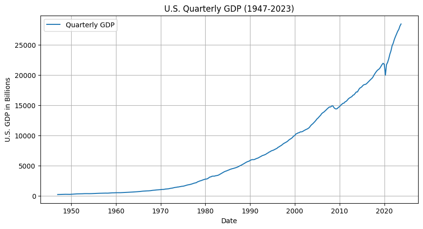

```python
plt.figure(figsize=(10,5))

# Set observation date to index and plot
gdp_data = gdp_data.set_index('observation_date')
plt.plot(gdp_data.index, gdp_data['GDP'], label='Quarterly GDP')

# Set titles, labels, and display
plt.title('U.S. Quarterly GDP (1947-2023)')
plt.xlabel('Date')
plt.ylabel('U.S. GDP in Billions')
plt.legend()
plt.grid(True)
plt.show()
```

### Model Determination

#### Decompose the Series

Now, we decompose the GDP data into its trend, seasonal, and residual components. I'm using multiplicative trend and multiplicative seasonality for this decomposition because:

- GDP compounds on itself rather than being a fixed increment, which implies multiplicative trend
- Fluctuations that are seasonal increase in magnitude as GDP is higher, which implies multiplicative seasonality

```python
fit1 = ExponentialSmoothing(gdp_data['GDP'], seasonal_periods=4, trend='mul', seasonal='mul', use_boxcox=False).fit(optimized=True, remove_bias=True)
```

```
                       ExponentialSmoothing Model Results
================================================================================
Dep. Variable:                      GDP   No. Observations:                  308
Model:             ExponentialSmoothing   SSE                        8340276.773
Optimized:                         True   AIC                           3159.604
Trend:                   Multiplicative   BIC                           3189.445
Seasonal:                Multiplicative   AICC                          3160.345
Seasonal Periods:                     4   Date:                 Sat, 18 Oct 2025
Box-Cox:                          False   Time:                         22:45:23
Box-Cox Coeff.:                    None
=================================================================================
                          coeff                 code              optimized
---------------------------------------------------------------------------------
smoothing_level               0.8985916                alpha                 True
smoothing_trend               0.0663902                 beta                 True
smoothing_seasonal             0.000000                gamma                 True
initial_level                 257.63754                  l.0                 True
initial_trend                 1.0091275                  b.0                 True
initial_seasons.0             1.0007443                  s.0                 True
initial_seasons.1             0.9971538                  s.1                 True
initial_seasons.2             1.0019326                  s.2                 True
initial_seasons.3             1.0023591                  s.3                 True
---------------------------------------------------------------------------------
```

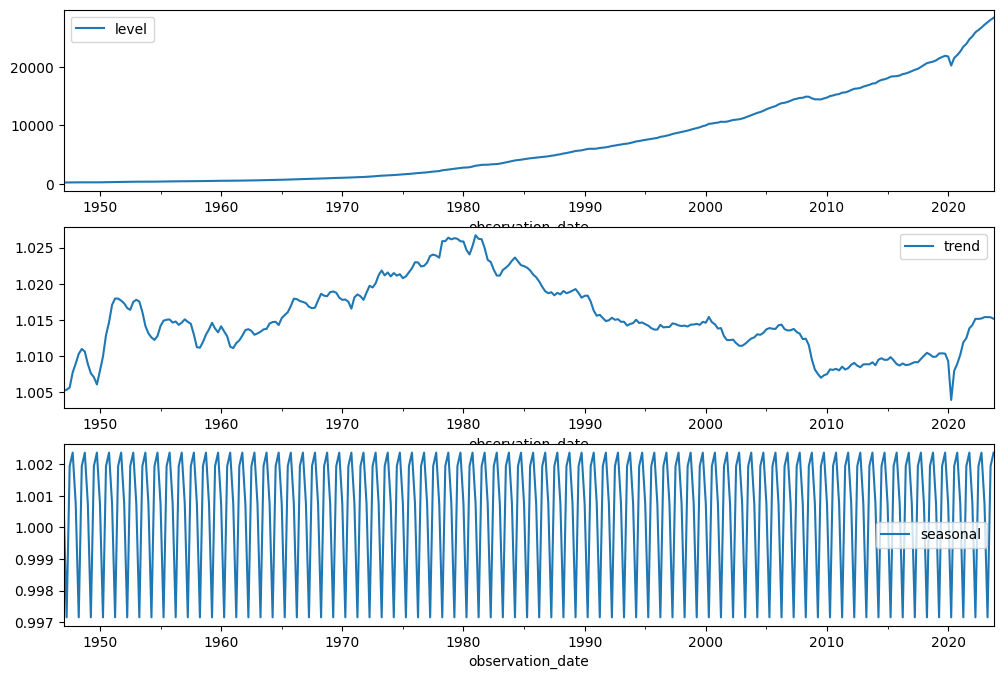

```python
print(fit1.summary())

states1 = pd.DataFrame(np.c_[fit1.level, fit1.trend, fit1.season], columns=['level','trend','seasonal'], index=gdp_data.index)

fig, [ax1,ax2,ax3] = plt.subplots(3, 1, figsize=(12,8))
states1[['level']].plot(ax=ax1)
states1[['trend']].plot(ax=ax2)
states1[['seasonal']].plot(ax=ax3)
```

#### Testing for Stationarity

Now we use the Augmented Dickey-Fuller (ADF) test to assess our model for stationarity. It is critical to make this assessment as stationarity is an assumption that many models like ARIMA require. We use a max lag of 4 since our data is quarterly.

```python
ro = adfuller(gdp_data['GDP'], regression='c', maxlag=4)

print ('ADF test statistic = ',ro[0])
print ('ADF critical value = ',ro[4])
```

```
ADF test statistic =  8.816418362294044
ADF critical value =  {'1%': -3.4519023023726696, '5%': -2.8710320399170537, '10%': -2.57182745012602}
```

For the ADF test, the Null Hypothesis is that the time series is non-stationary and the Alternative Hypothesis is that the time series is Stationary. For the Null Hypothesis to be rejected, the test statistic needs to be less than or equal to the critical value. Since the test statistic is 8.8164, and this is far larger than even the 10% critical value of -2.5718, we fail to reject the Null Hypothesis, indicating that our model is not stationary. As a result, we must apply differencing to our data to ensure that the condition of stationary is met.

#### Differencing to achieve stationarity

We perform first order differencing on the GDP data in order to make the time series stationary. As you can see, this resulted in a new model that rejects the ADF Test's Null Hypothesis and is thus a stationary series.

```python
gdp_datadiff= gdp_data['GDP'].diff(1).dropna()
d_ro = adfuller(gdp_datadiff, regression='c')

print ('ADF test statistic after differencing= ',d_ro[0])
print ('ADF critical value after differencing= ',d_ro[4])
```

```
ADF test statistic after differencing=  -3.750969648689495
ADF critical value after differencing=  {'1%': -3.4521902441030963, '5%': -2.871158406898617, '10%': -2.5718948388228586}
```

By subtracting every pair of consecutive observations, we create a series that is the measure of change in increment of the series. This effectively filters out the stochastic trend and unit root of our non-stionary series. Since our ADF test statistic = -3.7510 < the 1% critical value = -3.4522, our differenced model is statistically significantly stationary. **Thus, we get a differencing parameter d = 1**

#### Analyzing ACF/PACF Plots for non-seasonal components

Next, we look at the Autocorrelation (ACF) and Partial Autocorrelation (PACF) plots to determine the orders of the Autoregressive(p) and Moving Average(q) components of our ARIMA(p,d,q) model.

```
(-0.5, 0.5)
```

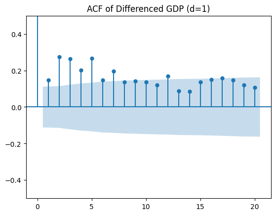

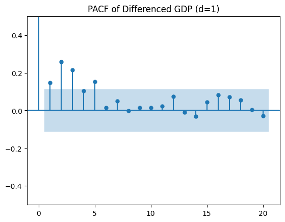

```python
# Create the ACF Plot
fig_acf = plot_acf(gdp_datadiff, lags=20) # Plot up to 20 lags
plt.title("ACF of Differenced GDP (d=1)")
plt.ylim(-0.5, 0.5) # Zoom in on the Y-axis to see the significant lags clearly


# Create the PACF Plot
fig_pacf = plot_pacf(gdp_datadiff, lags=20) # Plot up to 20 lags
plt.title("PACF of Differenced GDP (d=1)")
plt.ylim(-0.5, 0.5) # Zoom in on the Y-axis to see the significant lags clearly
```

The PACF plot demonstrates a "cut-off" effect, where after the fifth lag, every following lag fall within the confidence interval. This suggests the presence of an autoregressive process with hyperparameter **p = 5**.

The ACF plot, however, has a bit more ambiguity. It appears to tail off after a lag of 7 with a pulse at 12, but it's less clear whether there truly exists a non-seasonal moving average process. In order to reduce complexity, we'll leave our hyperparameter **q = 0**, but...

It does seem somewhat strange, however, that a lag of 12 produces a value outside of the confidence interval: this may potentially indicate that a component of Seasonal differencing is needed.

#### Seasonal Components

As the data is quarterly data, there is a clear component of seasonality with hyperparameter **s = 4**. Earlier, we noted that the there is spikes potentially every 4 lags. Therefore, now we will apply Seasonal Differencing **D = 1** and reanalyze the ACF and PACF plots following these differencing metrics.

```python
# Perform Additional Differencing on previous plot

gdp_datadiff2= gdp_datadiff.diff(4).dropna()
d_ro2 = adfuller(gdp_datadiff2, regression='c')

print ('ADF test statistic after non-seasonal and seasonal differencing= ',d_ro2[0])
print ('ADF critical value after non-seasonal and seasonal differencing= ',d_ro2[4])
```

```
ADF test statistic after non-seasonal and seasonal differencing=  -9.654838635320669
ADF critical value after non-seasonal and seasonal differencing=  {'1%': -3.4530232710482367, '5%': -2.871523926671883, '10%': -2.5720897694878424}
```

Applying the additional seasonal differencing has kept the series stationary as the ADF test statistics = -9.6548 is less than the 1% critical value of -3.4530, thus rejecting the Null Hypothesis of non-stationarity. Let's take a look at the ACF and PACF plots of the new series.

```
(-0.5, 0.5)
```

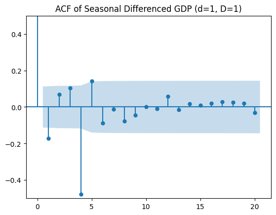

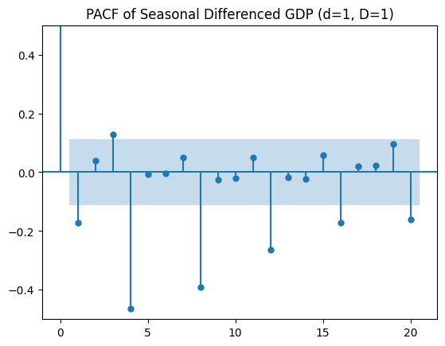

```python
# ACF plot after Seasonal Differencing
fig_acf = plot_acf(gdp_datadiff2, lags=20) # Plot up to 20 lags
plt.title("ACF of Seasonal Differenced GDP (d=1, D=1)")
plt.ylim(-0.5, 0.5) # Zoom in on the Y-axis to see the significant lags clearly


# PACF plot after Seasonal Differencing
fig_pacf = plot_pacf(gdp_datadiff2, lags=20) # Plot up to 20 lags
plt.title("PACF of Seasonal Differenced GDP (d=1, D=1)")
plt.ylim(-0.5, 0.5) # Zoom in on the Y-axis to see the significant lags clearly
```

Woah! The new PACF plot looks certainly worse, with a spike at every 4th lag; this likely indicates that we have over-differenced and that we should **not apply Seasonal Differencing**, and thus leave **D = 0**.

These plots, however, are helpful in determining our P and Q hyperparameters. Our Seasonal Differenced ACF plot shows a clear cut off at lag 4, which suggests seasonal moving average of **Q = 1**. We leave **P = 0** as the PACF doesn't convincingly cut off or tail off.

One benefit of examining these ACF/PACF plots with seasonal difference applied, is that it becomes clearer that the moving average is of a seasonal variety, rather than non-seasonal. So we can comfortably go with q = 0 and Q = 1.

#### First Model Hypothesis and Why

To conclude, our first model hypothesis for our series is **SARIMA(5, 1, 0) x (0, 0, 1)<sub>4</sub>**

We chose p = 5 because the PACF plot for d=1 exhibited cut off behavior, implying there was Autoregression with lag 5 present.

We chose d = 1 as the time series wasn't stationary and needed differencing to achieve stationarity.

We chose q = 0 as the ACF plot for d=1 was ambiguous, but upon examing seasonal differenced ACF plot, it was clearer that there was a component of seasonal moving average as opposed to non-seasonal moving average.

We chose s = 4 as our data is quarterly.

We chose P = 0 as the d=1,D=1 PACF plot demonstrated complex behavior that also didn't cut off or tail off.

We chose D = 0 as the d=1,D=1 PACF plot exhibited spikes at every lag that was a multiple of 4, which indicated to us that we over-differenced and that seasonal differencing was not necessary.

We chose Q = 1 as the d=1,D=1 ACF plot exhibited a strong cut off at lag 4, indicating that there was a component of seasonal moving average present in the data.

### Model Training and Evaluation

#### Splitting the training and testing data

We perform an 80/20 train-test split. The first 80% data is used to train and we test on the last 20%. This effectively helps us avoid any look-ahead bias.

```python
# Split the data into 80% train and 20% test data, where the train data is on the first 80% of the data and
# the test data is on the final 20% of the data

split = int(len(gdp_data) * 0.80)
y_train = gdp_data['GDP'].iloc[:split]
y_test = gdp_data['GDP'].iloc[split:]

# Check if splitting the training and testing data was done correctly
print(y_train.info())
print(y_test.info())
```

```
<class 'pandas.core.series.Series'>
DatetimeIndex: 246 entries, 1947-01-01 to 2008-04-01
Series name: GDP
Non-Null Count  Dtype
--------------  -----
246 non-null    float64
dtypes: float64(1)
memory usage: 3.8 KB
None
<class 'pandas.core.series.Series'>
DatetimeIndex: 62 entries, 2008-07-01 to 2023-10-01
Series name: GDP
Non-Null Count  Dtype
--------------  -----
62 non-null     float64
dtypes: float64(1)
memory usage: 992.0 bytes
None
```

#### Train our SARIMA model on training data

Now we define our SARIMA model parameters, and fit it into our chosen model: SARIMA(5, 1, 0) x (0, 0, 1)<sub>4</sub>

```python
# Hyperparameters
order = (5, 1, 0) #(p, d, q)
seasonal_order = (0, 0, 1, 4) #(P, D, Q, s)

model = SARIMAX(
    y_train,
    order=order,
    seasonal_order=seasonal_order,
    enforce_stationarity=False,
    enforce_invertibility=False
).fit(disp=-1)

print(model.summary())
```

```
                                      SARIMAX Results
===========================================================================================
Dep. Variable:                                 GDP   No. Observations:                  246
Model:             SARIMAX(5, 1, 0)x(0, 0, [1], 4)   Log Likelihood               -1166.067
Date:                             Sat, 18 Oct 2025   AIC                           2346.135
Time:                                     22:48:14   BIC                           2370.499
Sample:                                 01-01-1947   HQIC                          2355.952
                                      - 04-01-2008
Covariance Type:                               opg
==============================================================================
                 coef    std err          z      P>|z|      [0.025      0.975]
------------------------------------------------------------------------------
ar.L1          0.2906      0.051      5.732      0.000       0.191       0.390
ar.L2          0.2785      0.040      6.891      0.000       0.199       0.358
ar.L3         -0.0738      0.044     -1.674      0.094      -0.160       0.013
ar.L4          0.6378      0.067      9.556      0.000       0.507       0.769
ar.L5         -0.1106      0.066     -1.670      0.095      -0.240       0.019
ma.S.L4       -0.7550      0.063    -11.957      0.000      -0.879      -0.631
sigma2       959.0626     54.979     17.444      0.000     851.307    1066.819
===================================================================================
Ljung-Box (L1) (Q):                   0.03   Jarque-Bera (JB):               316.47
Prob(Q):                              0.86   Prob(JB):                         0.00
Heteroskedasticity (H):              75.40   Skew:                            -0.61
Prob(H) (two-sided):                  0.00   Kurtosis:                         8.49
===================================================================================

Warnings:
[1] Covariance matrix calculated using the outer product of gradients (complex-step).
```

#### Generate Forecasts with trained SARIMA model

Now we generate a forecast using our trained model for the next 62 observations (equal to the latter 20% of observations remaining)

```python
# Hard coded number of steps, but could easily do int(len(gdp_data) * 0.2)
predictions = model.forecast(steps=62)
```

Now let's plot it to take a look at how it compares with actual values

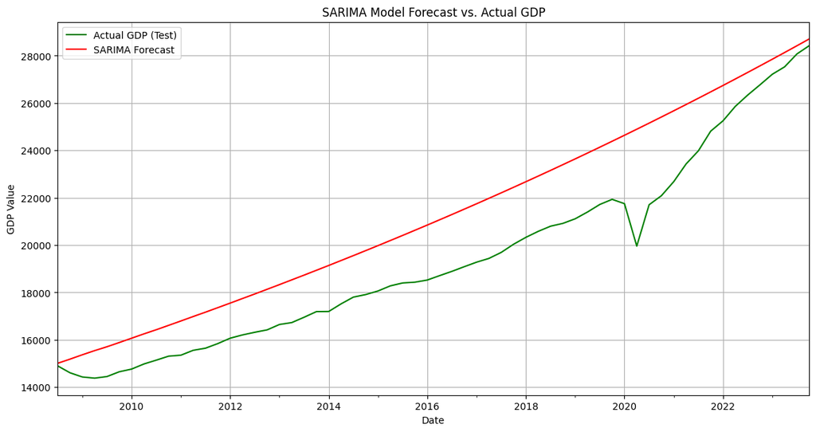

```python
# Create a single Data Frame to compare actual and predicted values
comparison_df = pd.DataFrame({
    'Actual_GDP': y_test,
    'Forecast_SARIMA': predictions
})

plt.figure(figsize=(14, 7))

comparison_df['Actual_GDP'].plot(ax=plt.gca(), label='Actual GDP (Test)', color='green')
comparison_df['Forecast_SARIMA'].plot(ax=plt.gca(), label='SARIMA Forecast', color='red')

plt.title('SARIMA Model Forecast vs. Actual GDP')
plt.xlabel('Date')
plt.ylabel('GDP Value')
plt.legend()
plt.grid(True)
plt.show()
```

Woah, that prediction is actually not bad. It doesn't seem to capture the convexity of the actual GDP or able to predict the 2020 COVID-19 pandemic, which resulted in a shrunken US GDP figure, but it did a good job at predicting as a whole.

#### Evaluate the model with metrics

```python
rmse = np.sqrt(mean_squared_error(y_test, predictions))
mae = mean_absolute_error(y_test, predictions)
mape = np.mean(np.abs((y_test - predictions) / y_test)) * 100

print("Evaluation Metrics:")
print("Root Mean Squared Error (RMSE):", rmse)
print("Mean Absolute Error (MAE):", mae)
print("Mean Absolute Percentage Error (MAPE):", mape)
```

```
Evaluation Metrics:
Root Mean Squared Error (RMSE): 2017.9238264791786
Mean Absolute Error (MAE): 1842.717234632483
Mean Absolute Percentage Error (MAPE): 9.692187717408478
```

#### Interpreting our Evaluation Metrics

RMSE measures the square root of the average of the squared errors. Because the errors are squared before being averaged, the RMSE is sensitive to both outliers and the variance in the forecast errors. The measure of error is scale-dependent. **Our RMSE of 2017.9238** means that the typical error magnitude is $2017.92 billion.

MAPE measures the average absolute error as a percentage of the actual value. This is a scale-independent metric, which is useful in interpreting error in proportion to the actual value. **Our MAPE of 9.692** means that, on average, our SARIMA forecast deviated from the actual GDP value by 9.69%. This suggests that while it did a good job at capturing overall trend and seasonal patterns, it did a poor job at handling periods of economic volatility (like the 2020 Covid pandemic).

### Comparative Analysis

#### Creating a Second Model for Comparison

For our second model, we will use the pmdarima library's 'auto_arima' function to determine the best hyperparameters for our SARIMAX model. It does so by automating the parameter selection, uses ADF to automatically choose the best order of differencing, and handles seasonality. Through this automation, it selects the best model based off of information criteria like AIC.

```python
import warnings
# Filter out warnings related to deprecation and FutureWarning
warnings.filterwarnings('ignore', category=FutureWarning)
warnings.filterwarnings('ignore', category=DeprecationWarning)

print(pm.arima.ndiffs(gdp_data['GDP']))
```

```
2
```

```python
secondmodel = pm.auto_arima(gdp_data['GDP'], start_p=0, start_q=0,
                      test='adf',       # use adftest to find optimal 'd'
                      max_p=6, max_q=6, # maximum p and q
                      m=4,              # frequency of series = 1 if no seasonality
                      d=None,            # d=0 if no first-differencing is necessary, d=None if you let pmdarima decide
                      seasonal=True,    #Seasonality = False if no seasonality
                      start_P=0,
                      D=0,              #D=0 if no seasonal differencing is necessary
                      trace=True,
                      error_action='ignore',
                      suppress_warnings=True,
                      stepwise=True)

print(secondmodel.summary())
```

```
Performing stepwise search to minimize aic
 ARIMA(0,1,0)(0,0,1)[4] intercept   : AIC=4084.785, Time=0.18 sec
 ARIMA(0,1,0)(0,0,0)[4] intercept   : AIC=4093.540, Time=0.03 sec
 ARIMA(1,1,0)(1,0,0)[4] intercept   : AIC=4083.659, Time=0.16 sec
 ARIMA(0,1,1)(0,0,1)[4] intercept   : AIC=4085.635, Time=0.17 sec
 ARIMA(0,1,0)(0,0,0)[4]             : AIC=4156.586, Time=0.03 sec
 ARIMA(1,1,0)(0,0,0)[4] intercept   : AIC=4088.807, Time=0.07 sec
 ARIMA(1,1,0)(2,0,0)[4] intercept   : AIC=4082.268, Time=0.31 sec
 ARIMA(1,1,0)(2,0,1)[4] intercept   : AIC=4070.879, Time=0.44 sec
 ARIMA(1,1,0)(1,0,1)[4] intercept   : AIC=4063.830, Time=0.24 sec
 ARIMA(1,1,0)(0,0,1)[4] intercept   : AIC=4085.032, Time=0.12 sec
 ARIMA(1,1,0)(1,0,2)[4] intercept   : AIC=4075.314, Time=0.42 sec
 ARIMA(1,1,0)(0,0,2)[4] intercept   : AIC=4085.287, Time=0.27 sec
 ARIMA(1,1,0)(2,0,2)[4] intercept   : AIC=inf, Time=0.57 sec
 ARIMA(0,1,0)(1,0,1)[4] intercept   : AIC=inf, Time=0.11 sec
 ARIMA(2,1,0)(1,0,1)[4] intercept   : AIC=4063.802, Time=0.29 sec
 ARIMA(2,1,0)(0,0,1)[4] intercept   : AIC=4069.047, Time=0.09 sec
 ARIMA(2,1,0)(1,0,0)[4] intercept   : AIC=4068.825, Time=0.05 sec
 ARIMA(2,1,0)(2,0,1)[4] intercept   : AIC=4065.865, Time=0.68 sec
 ARIMA(2,1,0)(1,0,2)[4] intercept   : AIC=4061.683, Time=0.50 sec
 ARIMA(2,1,0)(0,0,2)[4] intercept   : AIC=4070.444, Time=0.17 sec
 ARIMA(2,1,0)(2,0,2)[4] intercept   : AIC=inf, Time=0.64 sec
 ARIMA(3,1,0)(1,0,2)[4] intercept   : AIC=4059.620, Time=0.26 sec
 ARIMA(3,1,0)(0,0,2)[4] intercept   : AIC=4057.626, Time=0.20 sec
 ARIMA(3,1,0)(0,0,1)[4] intercept   : AIC=4055.671, Time=0.05 sec
 ARIMA(3,1,0)(0,0,0)[4] intercept   : AIC=4055.310, Time=0.03 sec
 ARIMA(3,1,0)(1,0,0)[4] intercept   : AIC=4055.626, Time=0.09 sec
 ARIMA(3,1,0)(1,0,1)[4] intercept   : AIC=4057.580, Time=0.34 sec
 ARIMA(2,1,0)(0,0,0)[4] intercept   : AIC=4068.767, Time=0.03 sec
 ARIMA(3,1,1)(0,0,0)[4] intercept   : AIC=4036.970, Time=0.20 sec
 ARIMA(3,1,1)(1,0,0)[4] intercept   : AIC=4040.206, Time=0.40 sec
 ARIMA(3,1,1)(0,0,1)[4] intercept   : AIC=4040.610, Time=0.32 sec
 ARIMA(3,1,1)(1,0,1)[4] intercept   : AIC=4053.455, Time=0.45 sec
 ARIMA(2,1,1)(0,0,0)[4] intercept   : AIC=4035.203, Time=0.18 sec
 ARIMA(2,1,1)(1,0,0)[4] intercept   : AIC=4037.319, Time=0.29 sec
 ARIMA(2,1,1)(0,0,1)[4] intercept   : AIC=4037.313, Time=0.35 sec
 ARIMA(2,1,1)(1,0,1)[4] intercept   : AIC=inf, Time=0.37 sec
 ARIMA(1,1,1)(0,0,0)[4] intercept   : AIC=4038.482, Time=0.13 sec
 ARIMA(2,1,2)(0,0,0)[4] intercept   : AIC=4037.101, Time=0.22 sec
 ARIMA(1,1,2)(0,0,0)[4] intercept   : AIC=4035.682, Time=0.19 sec
```

[output cut: 26 more lines]

```
                 coef    std err          z      P>|z|      [0.025      0.975]
------------------------------------------------------------------------------
ar.L1          0.8540      0.024     35.008      0.000       0.806       0.902
ar.L2          0.1436      0.022      6.615      0.000       0.101       0.186
ma.L1         -0.8945      0.023    -39.335      0.000      -0.939      -0.850
sigma2      2.881e+04    437.532     65.857      0.000     2.8e+04    2.97e+04
===================================================================================
Ljung-Box (L1) (Q):                   0.01   Jarque-Bera (JB):             96510.19
Prob(Q):                              0.92   Prob(JB):                         0.00
Heteroskedasticity (H):            1445.54   Skew:                            -3.26
Prob(H) (two-sided):                  0.00   Kurtosis:                        89.62
===================================================================================

Warnings:
[1] Covariance matrix calculated using the outer product of gradients (complex-step).
```

From auto_arima, **our second candidate model is SARIMA(2,1,1)(0,0,0)$_{4}$**.

#### Comparing the 2 Models' Performance

Next, we fit a new SARIMA model with our new hyperparameters, train and test our model, then calculate the evaluation metrics for our second model.

```python
# Hyperparameters
order2 = (2, 1, 1) #(p, d, q)
seasonal_order2 = (0, 0, 0, 4) #(P, D, Q, s)

model2 = SARIMAX(
    y_train,
    order=order2,
    seasonal_order=seasonal_order2,
    enforce_stationarity=False,
    enforce_invertibility=False
).fit(disp=-1)

print(model.summary())


predictions2 = model2.forecast(steps=62)

actual = y_test.values
forecast2 = predictions2.values

rmse2 = np.sqrt(mean_squared_error(actual, forecast2))
mae2 = mean_absolute_error(actual, forecast2)
mape2 = np.mean(np.abs((actual - forecast2) / actual)) * 100

print("Evaluation Metrics:")
print("Root Mean Squared Error (RMSE):", rmse2)
print("Mean Absolute Error (MAE):", mae2)
print("Mean Absolute Percentage Error (MAPE):", mape2)
```

[output not shown]

Comparing the Evaluation Metrics between the 2 candidate models:

- Model 1's RMSE is 2017.92 and Model 2's RMSE is 2277.94
- Model 1's MAE is 1842.72 and Model 2's MAE is 1455.25
- Model 1's MAPE is 9.69% and Model 2's MAPE is 6.49%

This suggests the following: Model 1 having a lower RMSE indicates that it performs better in worst-case performance as it appears to be less sensitive to outliers; however, that ultimately Model 2 is a better model as it has better average performance (MAE) as well as it's more accurate on a percentage basis (MAPE).

In conclusion, Model 2 would be a better general forecast model that generally has lower error, but suffers occaisionally from the influence of outliers.

#### Strengths and Weaknesses to Both

Strengths to Model 1:

- More transparency as the parameters chosen can be directly linked to the visual patterns present in the ACF/PACF plots
- Better Worst-Case Performance as it had a lower RMSE, which suggests more stability in volatle circumstances

Weaknesses to Model 1:

- Average Performance was worse with larger forecast errors than the auto-selected Model 2
- Difficult to rationalize decisions behind the ACF/PACF plots as a decision was made to leave q = 0 despite there being spikes that fell outside the confidence interval
- It was more time-intensive to replot, add further differencing, and re-evaluate after each step

Strengths to Model 2:

- Better Average Performance as it had lower MAE and MAPE, meaning that it forecasted better across the test set on average
- Model was chosen based off of well-established Statistical information criteria (the AIC)
- Automated and more efficient

Weaknesses to Model 2:

- Higher sensititvity to outliers, with a higher RMSE than Model 1 - indicates potentially failing to handle extreme events
- It's seemingly a black box, where it chose to get rid of all seasonal components (P,D,Q) despite there being a case to be made that seasonality plays a role in GDP data
- Potential Overfitting as stepwise models are rather susceptible to fitting to noise in the training data and being unreliable in the long run

## Task 2: Stationarity of Autoregressive Models

### Objective

The objective of this task is to prove that autoregressive models are stationary if and only if all the roots of its characteristic polynomial lie outside the unit circle, or in other words, that no unit roots exist.

#### Proving this property with AR(1)

By definition, the stationarity that we are assessing for in the AR(1) model is for weak stationarity. By definition, a process is weakly stationary if the Mean, Variance, and Autocovariance are invariant with time. If these 3 are time-invariant, then the mean and variance must be constant $\forall$ t, and the autocovariance must be both constant and only dependent on the Lag, $\mathcal{L}$.

Note that the lag operator is defined as the following expression:

$Y_{t-1} = \mathcal{L} Y_{t}$

The AR(1) Model is represented by the following equation:

$Y_t = \phi Y_{t-1} + \epsilon_{t}$ , where $\phi$ represents the autoregressive coefficient, and $\epsilon_{t}$ ~$N(\mu,\sigma^2)$, representing white noise

Bring the $Y$'s to one side:

$Y_t - \phi Y_{t-1} = \epsilon_{t}$

Apply the lag operator to $Y_{t-1}$:

$Y_{t} - \phi \mathcal{L} Y_{t} = \epsilon_{t}$

Combine like terms and we get:

$ (1 - \phi \mathcal{L}) Y_{t} = \epsilon_{t}$

From this, we get our lag polynomial:

$ \Phi(\mathcal{L}) = (1 - \phi \mathcal{L})$

Now, we need to move from operating in time (with lags) to operating algebraically (finding a polynomial's roots). Curiously, the characteristic polynomial $p(z)$ and the lag operator polynomial $\Phi(\mathcal{L})$ share the same coefficients based on the principle of $z$-transform.$^4$ Through this, we can substitute $\mathcal{L} \longrightarrow z$

Thus,

$\phi(\mathcal{L}) = p(z)$ and $p(z) = 1 - \phi z$

Solving the characteristic polynomial, we get the auotregressive coefficient $\phi$:

$|z| = |\frac{1}{\phi}| > 1$

or $|\phi| < 1$

This proves to us that stationarity in the AR(1) process is equivalent with keeping $|\phi | < 1$. Now let's calculate the first and second moments as well as the mean, variance, and autocovariance.

Mean:

$\forall t, Y_{t} = \phi Y_{t-1} + \epsilon_{t}$

$ = \phi (\phi Y_{t-2} + \epsilon_{t-1}) + \epsilon_{t} = \phi^2 Y_{t-2} + \phi \epsilon_{t-1} + \epsilon_{t}$

$\vdots$

= $\sum_{i=0}^{\infty} \phi^{i} \epsilon_{t-i}$

$\mathbb{E}[Y_{t}] = \sum_{i=0}^{\infty} \phi^{i} \mathbb{E}[\epsilon_{t-i}] \hspace{0.5cm} = \hspace{0.5cm} \sum_{i=0}^{\infty} \phi^{i} \mu = \frac{\mu}{1 - \phi}, \hspace{1cm} \phi \neq 1$

Since $\mu$ is constant, if |$\phi$| < 1, $\mathbb{E}[Y_{t}]$ is constant.

Variance:

$Var(Y_{t})= Var(\phi Y_{t-1} + \epsilon_{t})$

$ = \phi^2 Var(Y_{t-1}) + Var(\epsilon_{t}) + 2\phi Cov(Y_{t-1}, \epsilon_{t})\hspace{0.5cm} = \hspace{0.5cm} \phi^2 Var(Y_{t-1}) + \sigma^2$

$ = \phi^2 Var(\phi Y_{t-2} + \epsilon_{t-1}) + \sigma^2 \hspace{0.5cm} = \hspace{0.5cm} \phi^4 Var(Y_{t-2}) + \sigma^2(\phi^2 + 1)$

$\vdots$

$\sum_{i=0}^{\infty} \phi^{2i} \sigma^2$

$\forall t, Var(Y_{t}) = \frac{\sigma^2}{1 - \phi^2}$

The variance is constant if $|\phi| < 1$.

Autocorrelation:

$\gamma(1) = Cov(Y_{t}, Y_{t-1}) = Cov(\phi Y_{t-1} + \epsilon_{t}, Y_{t-1}) = \phi Cov(Y_{t-1},Y_{t-1}) = \phi Var(Y_{t-1}) = \phi Var(Y_{t})$

$\gamma(2) = Cov(Y_{t}, Y_{t-2}) = Cov(\phi Y_{t-1}, Y_{t-2}) = \phi \gamma(1) = \phi^2 Var(Y_{t})$

$\vdots$

$\gamma(k) = \phi^{k} Var(Y_{t}) $

As long as $|\phi| < 1$ is defined, $Var(Y_{t})$ is constant, and autocorrelation only depends on our lag $k$.

Thus, all properties are met and our AR(1) process is stationary $\hspace{0.25cm} \blacksquare$

#### Proving this property with AR(p)

The AR(p) process is defined by the following equation:

$Y_t = \phi_1 Y_{t-1} + \phi_2 Y_{t-2} + ... + \phi_p Y_{t-p} + \epsilon_{t}$ , $\hspace{0.5cm}$ $\epsilon_{t}$ ~$N(\mu,\sigma^2)$

Similar to AR(1), we can apply the Lag Operator to get the following:

$Y_t - \phi_1 \mathcal{L} Y_t - \phi_2 \mathcal{L}^2 Y_t - ... - \phi_p \mathcal{L}^p Y_t = \epsilon_t$

We factor $Y_t$ to get the following Lag Operator Polynomial:

$(1 - \sum_{i=1}^p \phi_i \mathcal{L}^i) Y_t = \epsilon_t$

$\Phi(\mathcal{L}) = (1 - \sum_{i=1}^p \phi_i \mathcal{L}^i)$

Again, we can utilize the same process as AR(1) and substitute the lag operator polynomial for the characteristic polynomial $p(z)$:

$p(z) = 1 - \sum_{i=1}^p \phi_i z^i $

$ p(z) = 1 - \phi_1 z - \phi_2 z^2 - ... - \phi_p z^p = 0$

From our characteristic polynomial, we understand that we'll have p complex roots, $z_1, z_2, ..., z_p$

However, there is an easier way than manually calculating for every single root. An AR(p) process can be written as an MA($\infty$) process because each shock term influences every subsequent value in the series. Using this knowledge, we can rewrite the formula as the following:

$Y_t = \Phi(\mathcal{L})^{-1} \epsilon_t = \sum_{j=0}^{\infty} \psi_j \epsilon_{t-j}$

For the AR(p) process to be weakly stationary, the Variance must be finite.

$Var(Y_t) = \sum_{j=0}^{\infty} \psi_{j}^2 Var(\epsilon_{t-j}) = \sigma_{\epsilon}^2 \sum_{j=0}^{\infty} \psi_{j}^2$

This process is stationary if and only if

$\sum_{j=0}^{\infty} \psi_{j}^2 < \infty$

The above series converges and $Y_t$ is finite if and only if all the roots $z_1,...,z_p$ of the characteristic equation lie outside of the unit circle $\blacksquare$

## Task 3: Implementing PCA

### Objective

The objective is to implement PCA without pre-existing libraries and analyze how well it performs.

### Implementation

#### Importing the Data

```python
# Numpy library is needed for us to implement PCA
import numpy as np

# Import Data and fix delimiters
redwine_quality = pd.read_csv("winequality-red.csv", sep=";")
whitewine_quality = pd.read_csv("winequality-white.csv", sep=";")


print(redwine_quality.info())
print(whitewine_quality.info())
```

```
<class 'pandas.core.frame.DataFrame'>
RangeIndex: 1599 entries, 0 to 1598
Data columns (total 12 columns):
 #   Column                Non-Null Count  Dtype
---  ------                --------------  -----
 0   fixed acidity         1599 non-null   float64
 1   volatile acidity      1599 non-null   float64
 2   citric acid           1599 non-null   float64
 3   residual sugar        1599 non-null   float64
 4   chlorides             1599 non-null   float64
 5   free sulfur dioxide   1599 non-null   float64
 6   total sulfur dioxide  1599 non-null   float64
 7   density               1599 non-null   float64
 8   pH                    1599 non-null   float64
 9   sulphates             1599 non-null   float64
 10  alcohol               1599 non-null   float64
 11  quality               1599 non-null   int64
dtypes: float64(11), int64(1)
memory usage: 150.0 KB
None
<class 'pandas.core.frame.DataFrame'>
RangeIndex: 4898 entries, 0 to 4897
Data columns (total 12 columns):
 #   Column                Non-Null Count  Dtype
---  ------                --------------  -----
 0   fixed acidity         4898 non-null   float64
 1   volatile acidity      4898 non-null   float64
 2   citric acid           4898 non-null   float64
 3   residual sugar        4898 non-null   float64
 4   chlorides             4898 non-null   float64
 5   free sulfur dioxide   4898 non-null   float64
 6   total sulfur dioxide  4898 non-null   float64
 7   density               4898 non-null   float64
 8   pH                    4898 non-null   float64
 9   sulphates             4898 non-null   float64
 10  alcohol               4898 non-null   float64
 11  quality               4898 non-null   int64
dtypes: float64(11), int64(1)
memory usage: 459.3 KB
None
```

#### Data Centering and Standardization

We need to perform data centering and standardization prior to calculating our Covariance Matrix. By centering our data, it ensures that the First Principal Component is not just simply the mean of the data, but rather the captures the maximum variance surrounding the mean. We also must perform scaling as PCA is sensitive to large magnitudes, so we need to ensure that ever feature has equal weight, and not just the case that the features with largest units of measurement get picked.

```python
# To Standardize, first calculate Mean and Standard Deviation of every Column, then perform (x - mu)/sigma
redcolmean = np.mean(redwine_quality, axis=0)
whitecolmean = np.mean(whitewine_quality, axis=0)
redcolstd = np.std(redwine_quality, axis=0)
whitecolstd = np.std(whitewine_quality, axis=0)


standard_red = (redwine_quality - redcolmean) / redcolstd
standard_white = (whitewine_quality - whitecolmean) / whitecolstd
```

#### Covariance Matrix Computation

We need to calculate each dataset's covariance matrix next because it allows us to calculate the variance of every factor as well as the covariance between every factor pair. This is crucial as when we later find the eigenvectors and eigenvalues of our Covariance Matrix, those will become our Principal Components(PC) and the magnitudes of each of those PC's.

```python
# Use Numpy.cov on our standardized data to get Covariance Mtarices
redcov_mat = np.cov(standard_red, rowvar = False)
whitecov_mat = np.cov(standard_white, rowvar = False)
```

#### Eigenvalue/Eigenvector Calculations

Calculating the eigenvectors and eigenvalues of our Covariance Matrix gives us our Principal Components and their magnitudes respectively.

```python
# Using Numpy's linalg.eigh gets the eigenvalues and eigenvectors of each covariance matrix
red_eigenval, red_eigenvect = np.linalg.eigh(redcov_mat)
white_eigenval, white_eigenvect = np.linalg.eigh(whitecov_mat)
```

#### Projection of Data onto Principal Components

First, we sort the eigenvalues in descending order. This sorts them by the magnitudes of each Principal Component/eigenvector from most important to least important.

```python
# We utilize Numpy's argsort to get an order of ascending values, using [::-1] to reverse for descending
sortedred = np.argsort(red_eigenval)[::-1]
sortedwhite = np.argsort(white_eigenval)[::-1]

# Sortedred and sortedwhite, however, are not the actual sorted array of PCs, but rather indices of the array of eigenvalues
# Now we need to actually sort the eigenvalues and eigenvectors by using these argsort arrays

sortedred_eigenval = red_eigenval[sortedred]
sortedwhite_eigenval = white_eigenval[sortedwhite]

# Note that here we need to use :, since that forces Numpy to reorder ONLY the columns, but that the rows are not scrambled
sortedred_eigenvect = red_eigenvect[:, sortedred]
sortedwhite_eigenvect = white_eigenvect[:, sortedwhite]
```

Now we need to project our data using the sorted eigenvectors and our standardized data. In order to accomplish this matrix multiplication correctly, we need to take the transpose of both these matrices, take the dot product of the two, then transpose again in order to get the correct final dimensions where the columns represent the Principal Components and the rows represent the samples.

```python
# Take the dot product of both the sorted eigenvectors and the standardized data
red_orderedbyPC = np.dot(sortedred_eigenvect.transpose(), standard_red.transpose()).transpose()
white_orderedbyPC = np.dot(sortedwhite_eigenvect.transpose(), standard_white.transpose()).transpose()


# Printing as a sanity check to see if performed correctly
print(red_orderedbyPC.shape)
print(white_orderedbyPC.shape)
print("Red Wine PC's Variance by Column: ", np.var(red_orderedbyPC, axis=0))
print("White Wine PC's Variance by Column: ", np.var(white_orderedbyPC, axis=0))
print("Red Sorted Eigenvalues: ", sortedred_eigenval)
print("White Sorted Eigenvalues: ", sortedwhite_eigenval)
```

```
(1599, 12)
(4898, 12)
Red Wine PC's Variance by Column:  [3.1211677  2.24188204 1.68291969 1.21502087 0.97326362 0.66259224
 0.6183178  0.50587256 0.41130754 0.32791939 0.18021863 0.05951792]
White Wine PC's Variance by Column:  [3.34666886 1.5860903  1.37117206 1.0848615  0.97528337 0.93876295
 0.76924825 0.72389378 0.55650103 0.34293339 0.28411542 0.02046911]
Red Sorted Eigenvalues:  [3.12312087 2.24328497 1.68397283 1.21578121 0.97387267 0.66300688
 0.61870473 0.50618912 0.41156493 0.3281246  0.18033141 0.05955516]
White Sorted Eigenvalues:  [3.34735228 1.58641419 1.37145206 1.08508304 0.97548253 0.93895465
 0.76940533 0.7240416  0.55661467 0.34300342 0.28417344 0.02047329]
```

After taking the dot product of the eigenvectors.T and standardized_data.T, we successfully projected our data onto our Principal Components. Taking the transpose again ensures that we have 12 columns representing our 12 Principal Components, each with X samples.

Calculating the Variance of each row on this sorted data, we get the Variance (and thus contribution) that each Principal Component contributes to the entire data as a whole. This array should match up with our array of eigenvalues, which it does.

#### Variance Explained Calculation

If we take a look at the array of sorted (in descending order) eigenvalues, each eigenvalue represents the variance of the data when its projected onto its corresponding principal component.

```python
print("Red Sorted Eigenvalues: ", sortedred_eigenval)
print("White Sorted Eigenvalues: ", sortedwhite_eigenval)
```

```
Red Sorted Eigenvalues:  [3.12312087 2.24328497 1.68397283 1.21578121 0.97387267 0.66300688
 0.61870473 0.50618912 0.41156493 0.3281246  0.18033141 0.05955516]
White Sorted Eigenvalues:  [3.34735228 1.58641419 1.37145206 1.08508304 0.97548253 0.93895465
 0.76940533 0.7240416  0.55661467 0.34300342 0.28417344 0.02047329]
```

We can take this one step further and sum all of the eigenvalues to get the total variance, then figure out the total proportion of the total variance each principal component makes up as well as the cumulative sum of the largest principal components' variances.

```python
# Calculate total variance
total_redvar = np.sum(sortedred_eigenval)
total_whitevar = np.sum(sortedwhite_eigenval)

# Calculate individual PC's explain variance proportion
expl_redvar = sortedred_eigenval / total_redvar
expl_whitevar = sortedwhite_eigenval / total_whitevar

# Calculate cumulative explained variance
cum_redvar = np.cumsum(expl_redvar)
cum_whitevar = np.cumsum(expl_whitevar)

# Create Data Frame of Explained Variance Ratios and Cumlative Explained Variance
df_red = pd.DataFrame({
    'PC Index': np.arange(1, len(sortedred_eigenval) + 1),
    'Eigenvalue': sortedred_eigenval,
    'Explained Variance Ratio (Proportion)': expl_redvar,
    'Cumulative Explained Variance': cum_redvar
})
df_white = pd.DataFrame({
    'PC Index': np.arange(1, len(sortedwhite_eigenval) + 1),
    'Eigenvalue': sortedwhite_eigenval,
    'Explained Variance Ratio (Proportion)': expl_whitevar,
    'Cumulative Explained Variance': cum_whitevar
})

print(df_red.to_string(index=False))
print(df_white.to_string(index=False))
```

```
 PC Index  Eigenvalue  Explained Variance Ratio (Proportion)  Cumulative Explained Variance
        1    3.123121                               0.260097                       0.260097
        2    2.243285                               0.186824                       0.446921
        3    1.683973                               0.140243                       0.587164
        4    1.215781                               0.101252                       0.688416
        5    0.973873                               0.081105                       0.769521
        6    0.663007                               0.055216                       0.824737
        7    0.618705                               0.051526                       0.876264
        8    0.506189                               0.042156                       0.918420
        9    0.411565                               0.034276                       0.952695
       10    0.328125                               0.027327                       0.980022
       11    0.180331                               0.015018                       0.995040
       12    0.059555                               0.004960                       1.000000
 PC Index  Eigenvalue  Explained Variance Ratio (Proportion)  Cumulative Explained Variance
        1    3.347352                               0.278889                       0.278889
        2    1.586414                               0.132174                       0.411063
        3    1.371452                               0.114264                       0.525328
        4    1.085083                               0.090405                       0.615733
        5    0.975483                               0.081274                       0.697006
        6    0.938955                               0.078230                       0.775237
        7    0.769405                               0.064104                       0.839341
        8    0.724042                               0.060324                       0.899665
        9    0.556615                               0.046375                       0.946040
       10    0.343003                               0.028578                       0.974618
       11    0.284173                               0.023676                       0.998294
       12    0.020473                               0.001706                       1.000000
```

Intepreting this, we see that the first 4 PC's for our red wine data capture 68.8% of the red wine data's variance. Similarly, we see that the first 5 PC's of our white wine data capture 69.7% of the white wine data's variance. Through these observations, we can greatly reduce our dimensions from 12 all the way down to 4,5, or how many depending on how much variance you want explained.

### Visualization & Analysis

#### OOP implementation of Red and White Wine Datasets

**Ok, so I think I misunderstood the assignment, but unfortunately now I understand.** I was meant to apply OOP principles by creating a function that would accept the red or white wine data and output the Principal Components. Rather than rewriting this entire section, I hope it's ok if I just create that PCA function here instead:

```python
def pca(data: pd.DataFrame, n_components: int = None) -> tuple:
    """
    Performs Principal Component Analysis (PCA) from scratch on a given dataset.

    Arguments: data (pd.DataFrame); n_components (int): Number of top PC's, if None return all PC's
    Returns: A tuple containing the following:
            - projected_data (np.ndarray): The data projected onto the principal components.
            - variance_df (pd.DataFrame): Table of explained and cumulative variance.
            - sorted_eigenvectors (np.ndarray): The principal components themselves.
    """
    # ------------------- 1. Data Centering/Standardization -------------------

    # axis=0 calculates mean/std column-wise (per feature)
    col_mean = np.mean(data, axis=0)
    col_std = np.std(data, axis=0)

    # Perform full standardization: (X - mu) / sigma
    standardized_data = (data - col_mean) / col_std

    # ------------------- 2. Covariance Matrix Computation  -------------------

    # Calculate the covariance matrix of the standardized data
    cov_mat = np.cov(standardized_data, rowvar=False)

    # ------------------- 3. Eigenvalue/Eigenvector Calculation ---------------

    # np.linalg.eigh is used for symmetric matrices (like the covariance matrix)
    eigen_values, eigen_vectors = np.linalg.eigh(cov_mat)

    # ------------------- 4. Sort Eigenvalues and Eigenvectors ------------------

    # Get indices for descending order sort
    sorted_index = np.argsort(eigen_values)[::-1]

    # Sort eigenvalues and eigenvectors
    sorted_eigenval = eigen_values[sorted_index]
    sorted_eigenvect = eigen_vectors[:, sorted_index] # Use [:, sorted_index] to reorder columns

    # ------------------- 5. Projection of Data onto Principal Components ------

    # Determine the subset of eigenvectors for projection
    if n_components is not None and n_components < len(sorted_eigenval):
        eigenvector_subset = sorted_eigenvect[:, 0:n_components]
    else:
        # Project onto all components if n_components is None or too large
        eigenvector_subset = sorted_eigenvect

    # Projection: (W.T @ Z.T).T where W is the subset of eigenvectors and Z is the standardized data
    # This results in a matrix (Samples x PCs)
    projected_data = np.dot(eigenvector_subset.transpose(), standardized_data.transpose()).transpose()


    # ------------------- 6. Variance Explained Calculation -------------------

    # Calculate individual PC's explained variance proportion
    total_variance = np.sum(sorted_eigenval)
    expl_var = sorted_eigenval / total_variance

    # Calculate cumulative explained variance
    cum_var = np.cumsum(expl_var)

    # Create the Explained Variance DataFrame
    variance_df = pd.DataFrame({
        'PC Index': np.arange(1, len(sorted_eigenval) + 1),
        'Eigenvalue': sorted_eigenval,
        'Explained Variance Ratio (Proportion)': expl_var,
        'Cumulative Explained Variance': cum_var
    }).set_index('PC Index')

    return projected_data, variance_df, sorted_eigenvect


    #-------------------- Implementation ------------------------

redwine = pd.read_csv("winequality-red.csv", sep=";")
whitewine = pd.read_csv("winequality-white.csv", sep=";")
print(pca(redwine))
print(pca(whitewine,3))
```

```
(array([[ 1.77944158, -1.15730315, -1.38658056, ..., -0.07311218,
        -0.2629366 , -0.0483618 ],
       [ 1.00418467, -2.07183784,  0.00775877, ...,  0.56573584,
         0.04878357,  0.13956516],
       [ 0.91578319, -1.3934342 , -0.69928641, ...,  0.16206469,
        -0.19914047,  0.120391  ],
       ...,
       [ 1.36626511,  0.51756099,  1.25069637, ...,  0.7528537 ,
         0.23526637,  0.4022917 ],
       [ 2.36714672, -0.70354479,  0.89948219, ...,  0.72345329,
         0.73725311, -0.03618731],
       [ 0.28877628,  1.24084585,  1.21809517, ..., -0.30587722,
         0.77724576,  0.44916727]]),           Eigenvalue  Explained Variance Ratio (Proportion)  \
PC Index
1           3.123121                               0.260097
2           2.243285                               0.186824
3           1.683973                               0.140243
4           1.215781                               0.101252
5           0.973873                               0.081105
6           0.663007                               0.055216
7           0.618705                               0.051526
8           0.506189                               0.042156
9           0.411565                               0.034276
10          0.328125                               0.027327
11          0.180331                               0.015018
12          0.059555                               0.004960

          Cumulative Explained Variance
PC Index
1                              0.260097
2                              0.446921
3                              0.587164
4                              0.688416
5                              0.769521
6                              0.824737
7                              0.876264
8                              0.918420
9                              0.952695
10                             0.980022
11                             0.995040
```

[output cut: 91 more lines]

[output not shown]

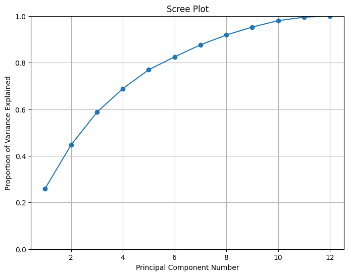

```python
# Run my PCA and unpack the results
red_projected_data, red_variance_table, red_pcs = pca(redwine)

# Extract the individual explained variance proportions
explained_variance_ratio = red_variance_table.iloc[:, 2].values


plt.figure(figsize=(8, 6))
plt.plot(range(1, len(explained_variance_ratio) + 1), explained_variance_ratio, marker='o', linestyle='-')
plt.title('Scree Plot')
plt.xlabel('Principal Component Number')
plt.ylabel('Proportion of Variance Explained')
plt.ylim(0,1.0)
plt.grid(True)
plt.show()
```

#### Visualize in 2D and 3D

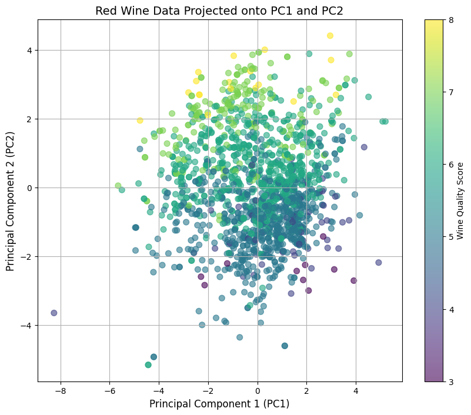

```python
# Load the data and extract quality scores
red_projected_data, red_variance_table, red_pcs = pca(redwine)
red_quality_scores = redwine_quality['quality']

# 2D Visualization
plt.figure(figsize=(10, 8))

# Scatter plot: PC1 (column 0) vs. PC2 (column 1)
scatter = plt.scatter(
    red_projected_data[:, 0],  # PC1 (X-axis)
    red_projected_data[:, 1],  # PC2 (Y-axis)
    c=red_quality_scores,      # Color by the original 'quality' score
    alpha=0.6,
    s=50
)

# Formatting
plt.title('Red Wine Data Projected onto PC1 and PC2', fontsize=14)
plt.xlabel('Principal Component 1 (PC1)', fontsize=12)
plt.ylabel('Principal Component 2 (PC2)', fontsize=12)

plt.colorbar(scatter, label='Wine Quality Score')
plt.grid(True)
plt.show()
```

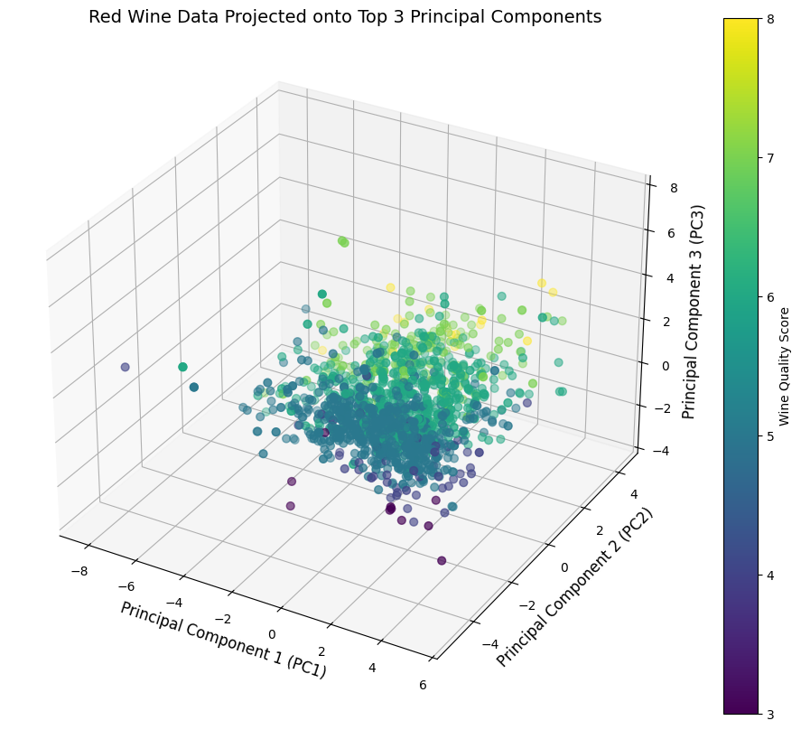

```python
# 3D Visualization

fig = plt.figure(figsize=(12, 10))
# Create a 3D subplot
ax = fig.add_subplot(111, projection='3d')

# Scatter plot: PC1, PC2, and PC3 (column 2)
scatter = ax.scatter(
    red_projected_data[:, 0],  # PC1 (X-axis)
    red_projected_data[:, 1],  # PC2 (Y-axis)
    red_projected_data[:, 2],  # PC3 (Z-axis)
    c=red_quality_scores,
    cmap='viridis',
    s=40
)

# Formatting
ax.set_title('Red Wine Data Projected onto Top 3 Principal Components', fontsize=14)
ax.set_xlabel('Principal Component 1 (PC1)', fontsize=12)
ax.set_ylabel('Principal Component 2 (PC2)', fontsize=12)
ax.set_zlabel('Principal Component 3 (PC3)', fontsize=12)


fig.colorbar(scatter, label='Wine Quality Score')
plt.show()
```

### Parameter Analysis

#### Effect of the Number of Components on Model Performance

The plot below shows how the classification accuracy changes with the number of components:

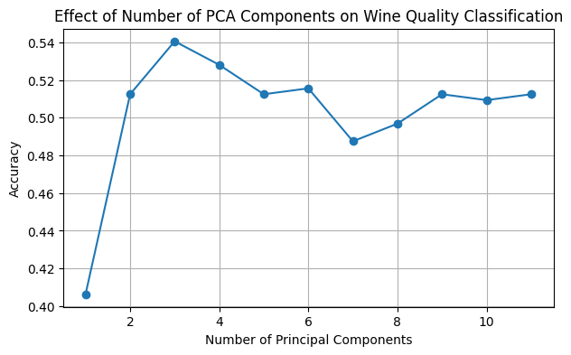

```python
from sklearn.model_selection import train_test_split
from sklearn.linear_model import LogisticRegression
from sklearn.metrics import accuracy_score

# Load data
redwine = pd.read_csv("winequality-red.csv", sep=";")

# Separate features (X) and target (y)
X = redwine.drop(columns=["quality"])
y = redwine["quality"]

# Split into train/test sets
X_train, X_test, y_train, y_test = train_test_split(X, y, test_size=0.2, random_state=42)


components_list = range(1, X.shape[1] + 1)  # from 1 to number of features
accuracies = []

for k in components_list:

    # Call my PCA
    projected_train, _, _ = pca(X_train, n_components=k)
    projected_test, _, _ = pca(X_test, n_components=k)

    # Train a simple logistic regression model
    model = LogisticRegression(max_iter=1000)
    model.fit(projected_train, y_train)

    # Calculate accuracy
    y_pred = model.predict(projected_test)
    acc = accuracy_score(y_test, y_pred)
    accuracies.append(acc)

# Plot results
plt.figure(figsize=(7, 4))
plt.plot(components_list, accuracies, marker='o')
plt.title("Effect of Number of PCA Components on Wine Quality Classification")
plt.xlabel("Number of Principal Components")
plt.ylabel("Accuracy")
plt.grid(True)
plt.show()
```

As shown, accuracy increases rapidly from one to three components, peaking around 0.53, then slightly decreases and stabilizes around the 0.50 mark for higher component counts. This indicates that the first few principal components (approximately 3) capture most of the information relevant to predicting wine quality, while additional components contribute little or even introduce noise that slightly reduces performance.

#### Analysis and Insights

The trend demonstrates a typical diminishing returns pattern often seen with PCA: The first components capture the most variance and thus the most informative structure in the data, but later components mainly capture smaller-scale variations or noise, which do not necessarily improve classification accuracy.

This suggests that for our red wine data here, that using roughly 3 principal components achieves a good trade-off between dimensionality reduction and predictive performance.

## References

Task 1:  
https://www.statsmodels.org/stable/generated/statsmodels.tsa.stattools.acf.html  
https://fiveable.me/introduction-econometrics/unit-8/autoregressive-models/study-guide/ztPtDKzdRtmt3YrM

Task 2:  
[3]: https://www.cmor-faculty.rice.edu/~heinken/latex/symbols.pdf  
[4]: https://www.uh.edu/~bsorense/arma-intro2012.pdf